# NAPED — Portfólio de Ações | Abril 2026

[figure not shown]

Afya São João del Rei

Portfólio de Ações  
NAPED

Abril de 2026

Registro das iniciativas desenvolvidas pelo Núcleo de Apoio Pedagógico e Experiência Docente

Ação 1 Abril 2026

Encontro com Médicos e Reitoria

Integração Institucional & Escuta Ativa

Encontro de alinhamento e integração institucional realizado na sala do NAPED, reunindo o Reitor, a equipe do NAPED e professores médicos da instituição. Em um ambiente acolhedor, com café e conversa próxima, o momento fortaleceu os vínculos entre gestão e docência, promovendo escuta ativa, troca de percepções sobre o cotidiano acadêmico e o alinhamento de perspectivas para o desenvolvimento do curso de Medicina.

[figure not shown]

Encontro na sala do NAPED — equipe NAPED, Reitoria e professores médicos

[figure not shown]

Momento de escuta e proximidade entre Reitoria e docentes

Ação 2 Abril 2026

NAPED Day 2026 — 7 Anos

Inteligência Artificial e Docência Sustentável

O NAPED Day é um evento nacional da Afya que ocorre uma única vez ao ano, organizado a partir do envolvimento de 30 instituições, e em 2026 celebrou seus **7 anos** com o tema *"Inteligência Artificial e Docência Sustentável"*, realizado em 18 de maio. No dia do evento não há aulas e todos os professores são convidados a participar de palestras, oficinas e cursos, com certificação. A mobilização local — divulgação, convites e organização — teve início em abril, culminando em uma programação que integrou o Dia D presencial e oficinas formativas online.

Divulgação

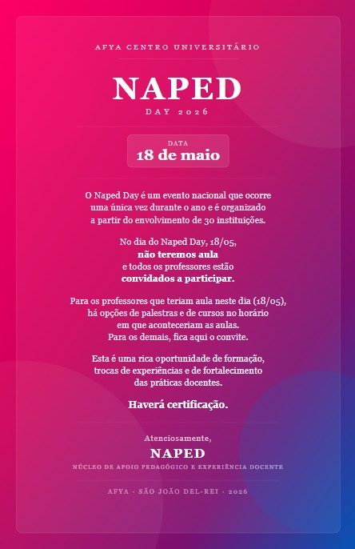

Convite institucional aos docentes — NAPED Day 2026, 18 de maio

[figure not shown]

Arte de divulgação «É Hoje!» — tema Inteligência Artificial e Docência Sustentável

Dia D — Celebração Local

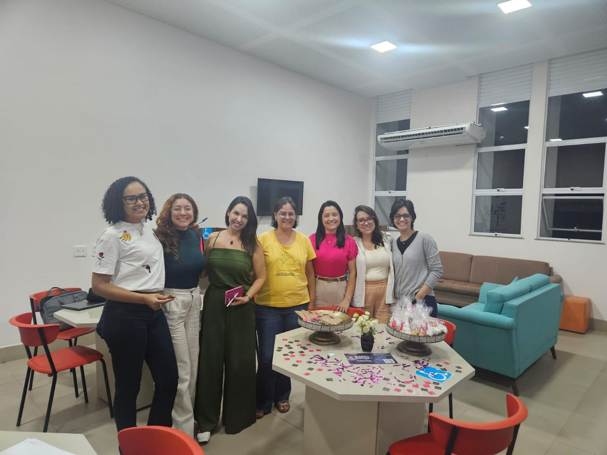

Equipe reunida no espaço de convivência — celebração dos 7 anos do NAPED

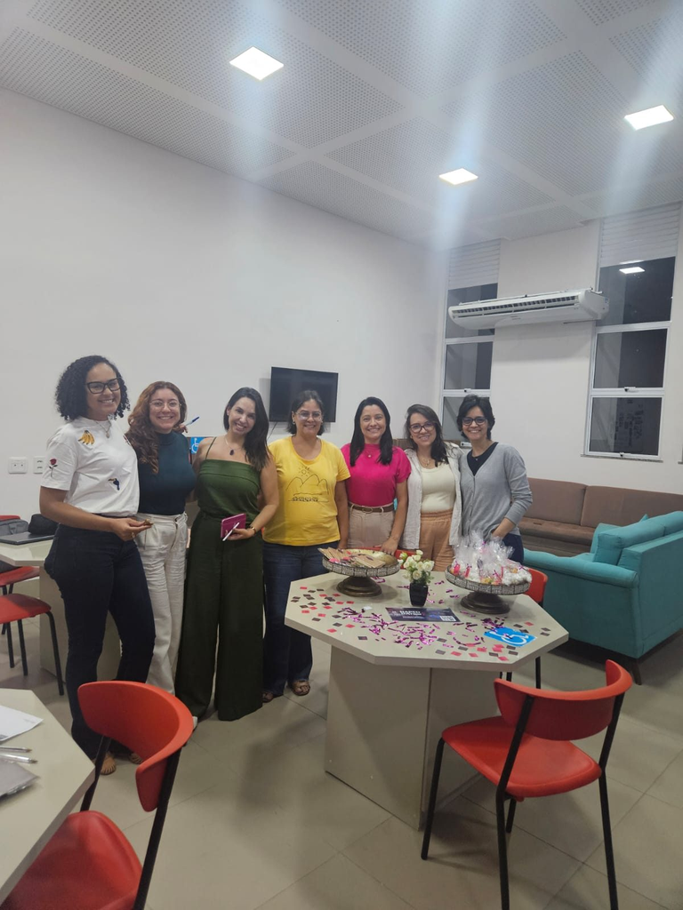

Registro da equipe com lembranças e mimos preparados para os docentes

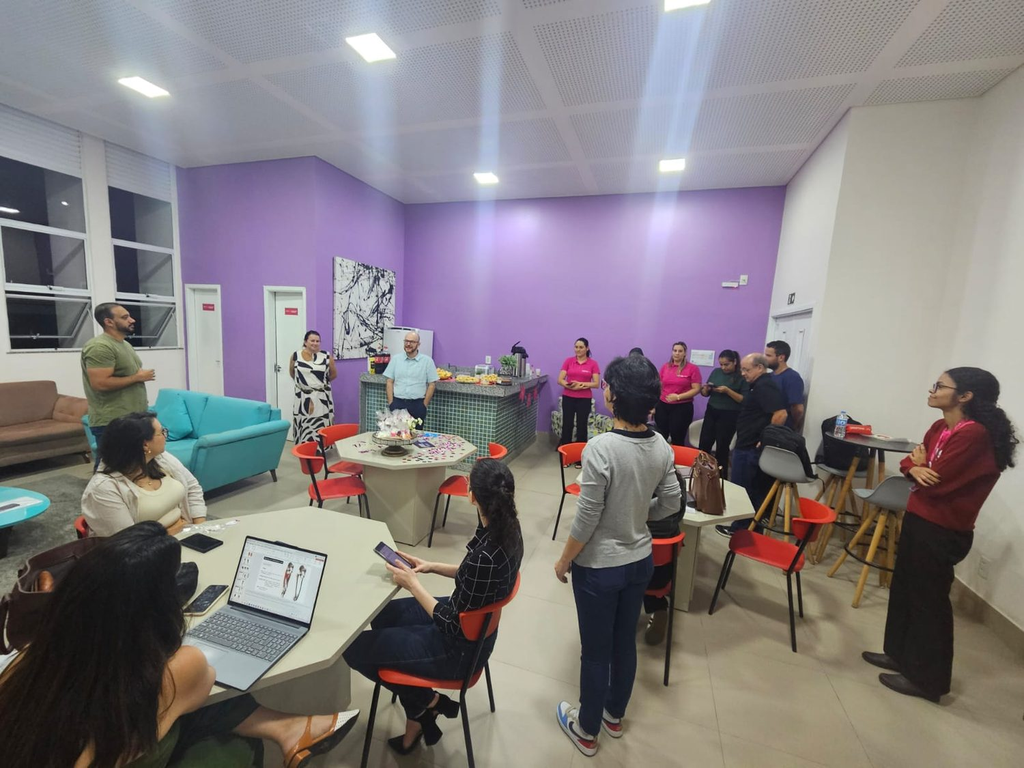

Momento de integração e acolhida dos participantes

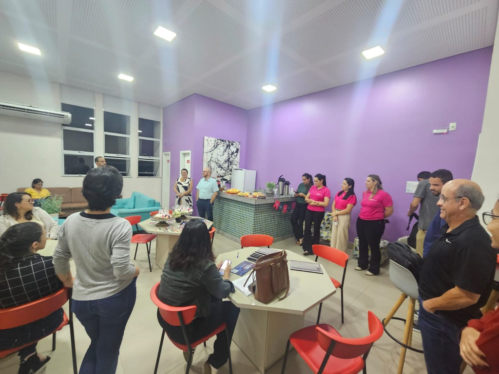

Confraternização entre docentes e equipe NAPED

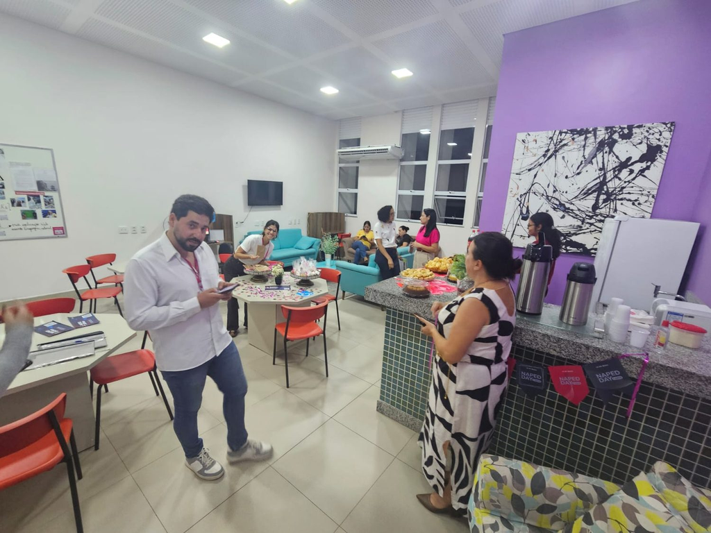

Café temático do NAPED Day com bandeirinhas comemorativas

[figure not shown]

Troca de experiências entre os participantes durante o Dia D

Oficinas

[figure not shown]

Oficina online — «O Aluno como Protagonista»: e-Learning e mediação docente

[figure not shown]

Oficina «Quando Não Há Paciente» — estratégias pedagógicas com participação dos docentes

Ação 3 Abril 2026

Projeto ENAMED

Avaliação Institucional & Edital nº 49/2026

Reunião de alinhamento sobre o **Edital nº 49, de 24 de abril de 2026**, que define os cursos avaliados no ciclo ENADE/ENAMED 2026 — com 36 cursos avaliados pelo INEP e previsão de 19 cursos com estudantes concluintes da Afya, incluindo Medicina (ingressantes, estudantes do 4º ano e concluintes). O encontro discutiu os critérios avaliativos e as estratégias de preparação institucional. Como desdobramento, o Reitor conduziu **conversas individuais com professores da Medicina**, em movimento de escuta que integra o projeto e qualifica o planejamento das ações voltadas ao ENAMED.

[figure not shown]

Reunião online de alinhamento — ENADE 2026: cursos avaliados (Edital nº 49, de 24/04/2026)

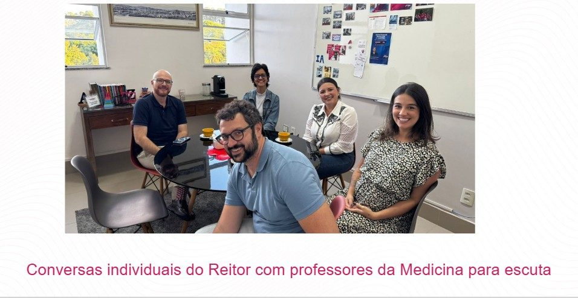

Conversas individuais do Reitor com professores da Medicina para escuta

NAPED — Afya São João del Rei

Portfólio Abril 2026

[figure not shown]